# Data Visualization in R

### 2.2.2 Kernel density Plot

An alternative to a histogram is the kernel density plot. Technically, kernel density estimation is a non parametric method for estimating the probability density function of a continuous random variable (what??). Basically, we are trying to draw a smoothened histogram. Where the area under the curve equals one.

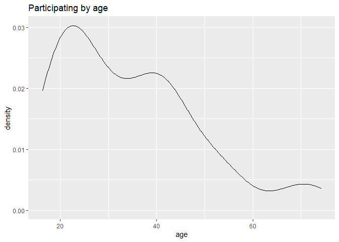

Kernel density plot

```r
# create a kernel density plot a age

ggplot(data = Marriage,
       mapping = aes(x = age)) +
  geom_density() +
  labs(title = "Participating by age")
```

The graph shows the distribution of scores. For example, the proportion of cases between 20 and 40 years old would be represented by the area under the curve between 20 and 40 on the x-axis.

As with previous charts, we can use fill and color to specify the fill and border colors.

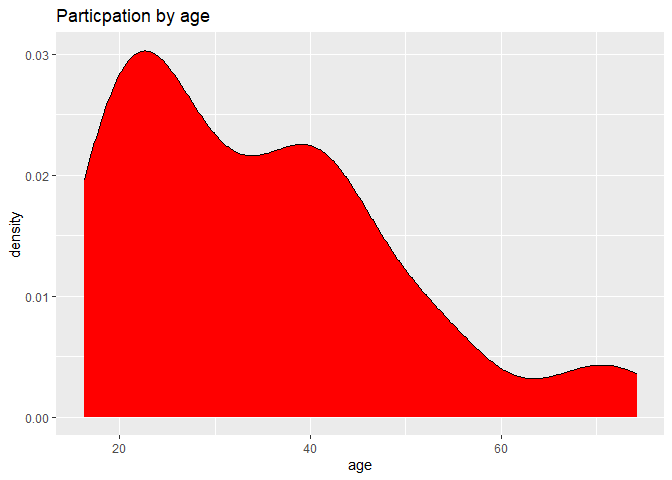

filled density plot

```r
ggplot(data = Marriage,
       mapping = aes(x = age)) +
         geom_density(fill = 'red')+
         labs(title = "Particpation by age")
```

**Smoothing parameter**

The degree of smoothness is controlled by the bandwidth parameter bw. To find the default value for a particular variable, use the bw.nrd0 function. Values that are larger will result in more smoothing, while values that are smaller will produce less smoothing.

```r
# default bandwidth for the age variable
bw.nrd0(Marriage$age)
```

```
## [1] 5.181946
```

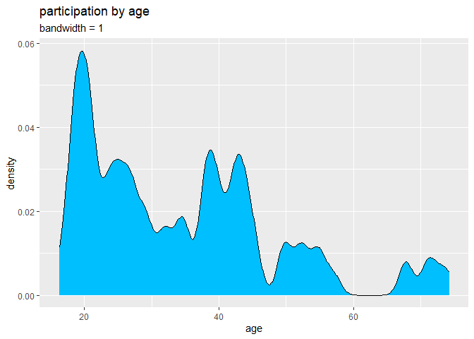

```r
# Create a kernel density plot of age
ggplot(data = Marriage,
       mapping = aes(x = age)) +
  geom_density(fill = 'deepskyblue',
               bw = 1) +
  labs(title = "participation by age",
       subtitle = "bandwidth = 1")
```

### 2.2.3 Dot chart

Another alternative to the histogram is the dot chart. Again, the quantitative variable is divided into bins, but rather than summary bars, each observation is represented by a dot. By default, the width of a dot corresponds to the bin width, and dots are stacked, with each dot representing one observation. This works best when the number of observations is small (say, less than 150).

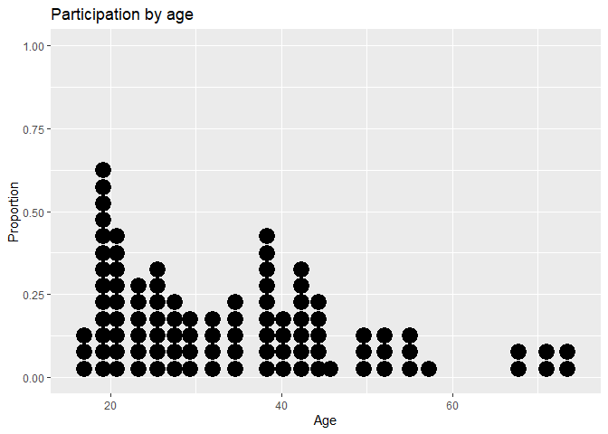

basic dot plot

```r
# Plot the age distribution using a dotplot
ggplot(data = Marriage,
       mapping = aes(x = age))+
  geom_dotplot() +
  labs(title = "Participation by age",
       y = "Proportion",
       x = "Age")
```

The *fill* and *color* options can be used to specify the fill and border color of each dot respectively.

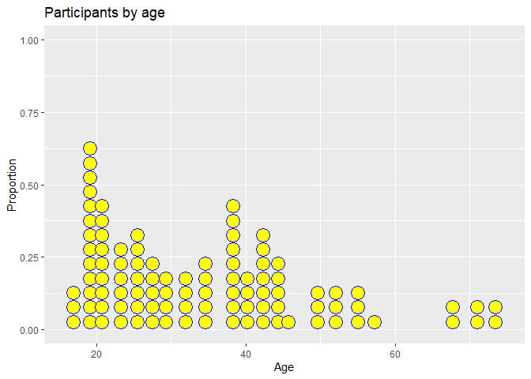

Filled dot plot

```r
# Plot ages as a dot plot using
# gold dots with black borders
ggplot(Marriage, aes(x = age)) +
  geom_dotplot(fill = "yellow",
               color="blue") +
  labs(title = "Participants by age",
       y = "Proportion",
       x = "Age")
```

# 3 Bivariate Graphs

One of the most fundamental questions in research is “What is the relation ship between two variables i.e., A and B”. Bivariate graphs display the relationship between two variables. The type of graph will depend on the measurement level of each variable (Categorical or quantitative).

## 3.1 Categorical vs. Categorical

When plotting the relationship between two categorical variables, stacked, grouped or segmented bar charts are typically used.

In this section, we will look at the automobile characteristics contained in mpg dataset that comes with the ggplot2 package. It provides fuel efficiency data for 38 popular car models in 1998 and 2008.

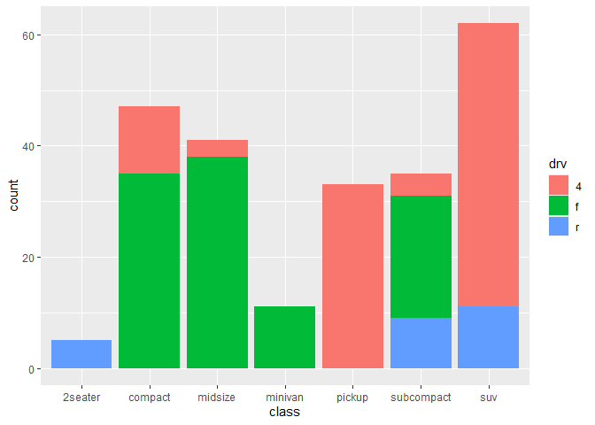

A stacked bar plot

```r
library(ggplot2)
# Stacked bar chart

ggplot(data = mpg,
       mapping = aes(x = class,
                     fill = drv)) +
  geom_bar(position = "stack")
```

From the Figure we can see for example, that the most common vehicle is the SUV. All 2 seater cars are rear wheel drive, while most, but not all SUVs are 4-wheel drive.

Stacked is the default, so the last line could have also been written as *geom_bar()*.

### 3.1.1 Grouped bar chart

Grouped bar charts place bars for the second categorical variable side-by-side. To create a grouped bar plot use the position = “dodge” option.

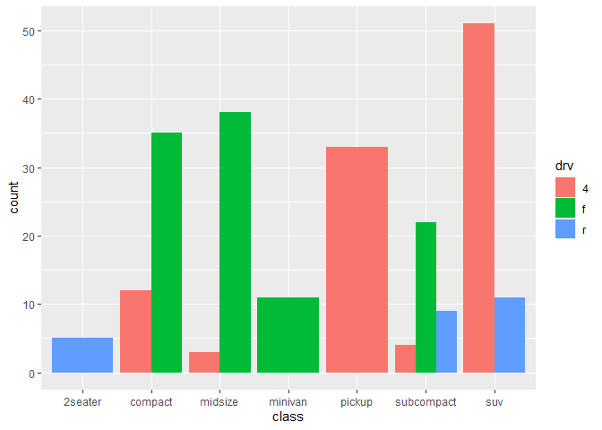

Side by side bar chart

```r
library(ggplot2)

ggplot(data = mpg,
       mapping = aes(x = class, fill = drv)) +
  geom_bar(position = "dodge")
```

Here all Minivars are front-wheel drive. By default, zero count bars are dropped and the remaining bars are made wider. This may not the behaviour we want. You can modify this using the position = position_dodge(preserve = “single”)

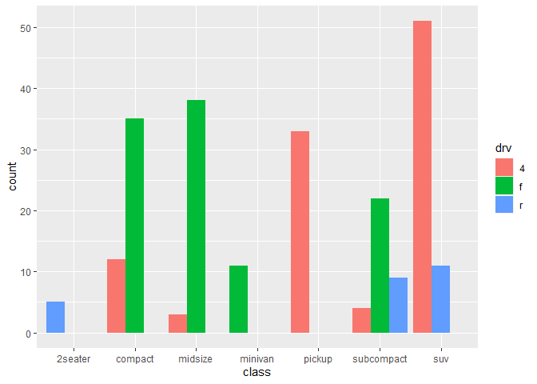

```r
library(ggplot2)

# grouped barplot preserving zero count bars

ggplot(data = mpg,
       mapping = aes(x = class,
                     fill = drv)) +
  geom_bar(position = position_dodge(preserve = "single"))
```

### Segmented bar chart

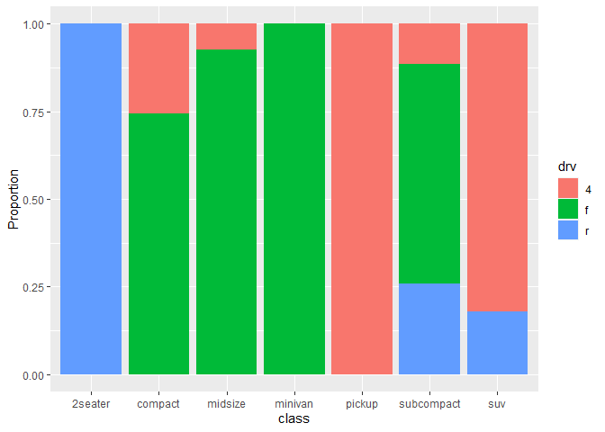

```r
library(ggplot2)

#bar plot, with each bar representing 100%
ggplot(data = mpg,
       aes(x = class,
           fill = drv)) +
  geom_bar(position = "fill") +
  labs(y = "Proportion")
```

This type of plot is particularly useful if the goal is to compare the percentage of a category in one variable across each level of another variable. For example, the proportion of front-wheel drive cars go up as you move from compact, to midsize, to minivan.

### 3.1.2 Improving the color and labeling

You can additional options to improve color and labeling. In the graph below

- factor modifies the order of the categories for the class variable and both the order and the labels for the drive variable
- scale_y_continuous modifies the y-axis tick mark labels
- labs provides a title and changed the labels for the x and y axes and the legend
- scale_fill_brewer changes the fill color scheme
- theme_minimal removes the grey background and changed the grid color

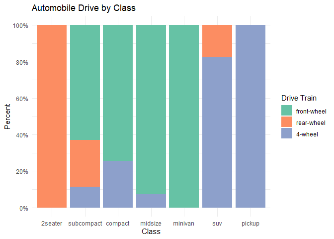

Segmented bar chart with improved labeling and color

```r
library(ggplot2)

# bar plot, with each bar representing 100%,
# reordered bars, and better labels and colors
library(scales)
ggplot(mpg,
       aes(x = factor(class,
                      levels = c("2seater", "subcompact",
                                "compact", "midsize",
                                "minivan", "suv", "pickup")),
           fill = factor(drv,
                         levels = c("f", "r", "4"),
                         labels = c("front-wheel",
                                    "rear-wheel",
                                    "4-wheel")))) +
  geom_bar(position = "fill") +
  scale_y_continuous(breaks = seq(0, 1, .2),
                     label = percent) +
  scale_fill_brewer(palette = "Set2") +
  labs(y = "Percent",
       fill="Drive Train",
       x = "Class",
       title = "Automobile Drive by Class") +
  theme_minimal()
```

Next, let’s add percent labels to each segment. First, we’ll create a summary dataset that has the necessary labels.

```r
# create a summary dataset

plot_data <- mpg %>%
  group_by(class, drv) %>%
  summarise(n = n()) %>%
  mutate(pct = n/sum(n),
         lbl = scales::percent(pct))
plot_data
```

```
## # A tibble: 12 × 5
## # Groups:   class [7]
##    class      drv       n    pct lbl
##    <chr>      <chr> <int>  <dbl> <chr>
##  1 2seater    r         5 1      100%
##  2 compact    4        12 0.255  26%
##  3 compact    f        35 0.745  74%
##  4 midsize    4         3 0.0732 7%
##  5 midsize    f        38 0.927  93%
##  6 minivan    f        11 1      100%
##  7 pickup     4        33 1      100%
##  8 subcompact 4         4 0.114  11%
##  9 subcompact f        22 0.629  63%
## 10 subcompact r         9 0.257  26%
## 11 suv        4        51 0.823  82%
## 12 suv        r        11 0.177  18%
```

Next, we’ll use this dataset and the geom_txt function to add labels to each bar segment.

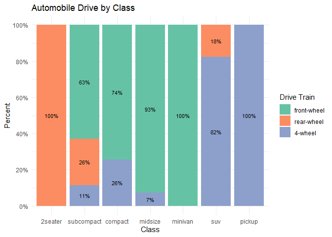

```r
# create segmented bar chart
# adding labels to each segment

ggplot(plot_data,
       aes(x = factor(class,
                      levels = c("2seater", "subcompact",
                                 "compact", "midsize",
                                 "minivan", "suv", "pickup")),
           y = pct,
           fill = factor(drv,
                         levels = c("f", "r", "4"),
                         labels = c("front-wheel",
                                    "rear-wheel",
                                    "4-wheel")))) +
  geom_bar(stat = "identity",
           position = "fill") +
  scale_y_continuous(breaks = seq(0, 1, .2),
                     label = percent) +
  geom_text(aes(label = lbl),
            size = 3,
            position = position_stack(vjust = 0.5)) +
  scale_fill_brewer(palette = "Set2") +
  labs(y = "Percent",
       fill="Drive Train",
       x = "Class",
       title = "Automobile Drive by Class") +
  theme_minimal()
```

## 3.2 Quantitative Vs. Quantitative

The relationship between two quantitative variables is typically displayed using scatter plot and line graphs.

### 3.2.1 Scatter plot

The simplest way of two quantitative variable is a scatter plot, with each variable represented on an axis. Here we will use **salary** dataset.

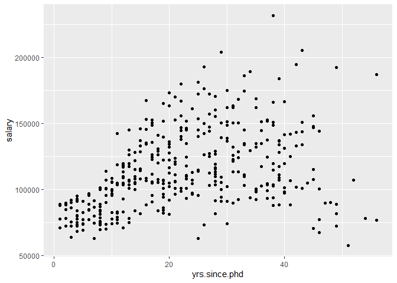

Basic Scatterplot

```r
library(ggplot2)
library(carData)

data(Salaries, package = "carData")

# simple scatter plot
ggplot(Salaries,
       aes(x = yrs.since.phd, y = salary)) +
  geom_point()
```

As expected, salary tends to rise with experience, but the relationship may not be strictly linear. Note that salary appears to fall off after about 40 years of experience.

The geom_point function has options that can be used to change the

- color : point color
- size : point size
- shape : point shape
- alpha : point transparency. Transparency ranges from 0 (transparent) to 1 (opaque), and is a useful parameter when points overlap.

The functions scale_x_continuous and scale_y_continuous control the scaling on x and y axes respectively.

We can use these options and functions to create a more attractive scatter plot.

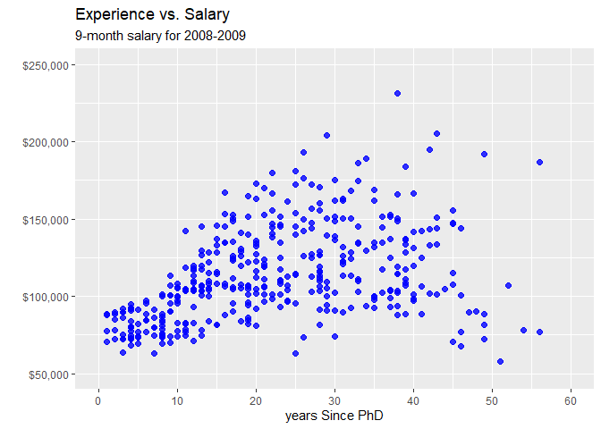

```r
# enhanced scatter plot
ggplot(data = Salaries,
       mapping = aes(x = yrs.since.phd, y = salary)) +
  geom_point(color = 'blue',
             size = 2,
             alpha = 0.8) +
  scale_y_continuous(label = scales::dollar,
                     limits = c(50000,250000)) +
  scale_x_continuous(breaks = seq(0,60,10),
                     limits = c(0,60))+
  labs(x = "years Since PhD",
       y = "",
       title = "Experience vs. Salary",
       subtitle = "9-month salary for 2008-2009")
```

#### 3.2.1.1 Adding best fit lines

It is often useful to summarize the relationship displayed in the scatter plot, using a best fit line. Many types of lines are supported, including linear, polynomial, and nonparametric (loess). By default, 95% confidence limits for these lines are displayed.

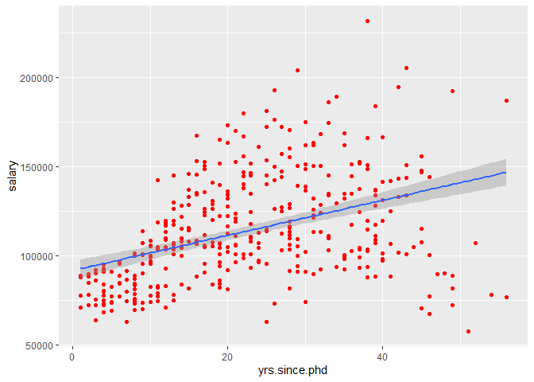

Scatter plot with linear fitting

```r
# Scatter plot with linear fit line
library(ggplot2)
library(carData)
ggplot(data = Salaries,
       mapping = aes(x = yrs.since.phd,
                     y = salary)) +
  geom_point(color = "red")+
  geom_smooth(method = "lm")
```

Clearly, salary increases with experience. However, there seems to be a dip at the right end - professors with significant experience, earning lower salaries. A straight line does not capture this non-linear effect. A line with a bend will fit better here.

A polynomial regression line provides a fit line of the form

$$\hat{y} = \beta_0 +\beta_1x +\beta_2x^2
+ \beta_3x^3 +........ \tag{i}$$

Typically either a quadratic (one bend), or cubic (two bends) line is used. It is rarely necessary to use a higher order( >3 ) polynomials. Adding a quadratic fit line to the salary dataset produces the following result.

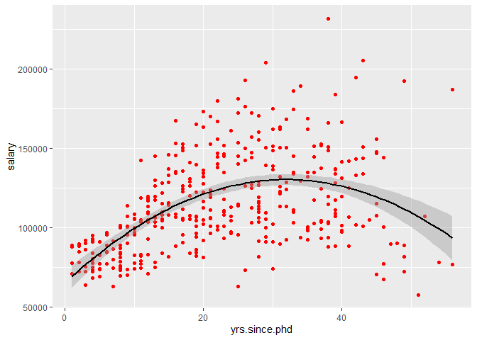

```r
# scatterplot with quadratic line of best fit
ggplot(Salaries, aes(x = yrs.since.phd, y = salary)) +
  geom_point(color= "red") +
  geom_smooth(method = "lm",
              formula = y ~ poly(x, 2),
              color = "black")
```

Finally, a smothened nonparametric fit line can often provide a good picture of relationship. The default in ggplot2 is a locally weighted scatterplot smoothing (loess).

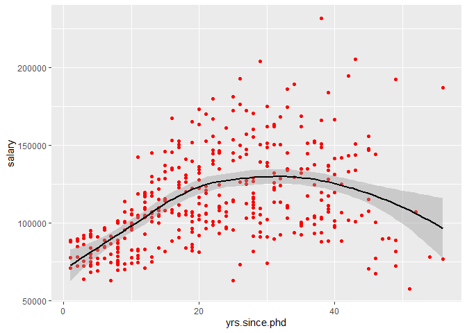

Scatter plot with non parametric fit line

```r
# Scatterplot with non parametric fit line
ggplot(Salaries, aes(x = yrs.since.phd, y = salary)) +
  geom_point(color= "red") +
  geom_smooth(color = 'black')
```

### 3.2.2 Line plot

When one of the two variables represents time, a line plot can be an effective method of displaying relationship. For example, the code below displays the relationship between time (year) and life expectancy (lifeExp) in the United States between 1952 and 2007. The data comes from the gapminder dataset.

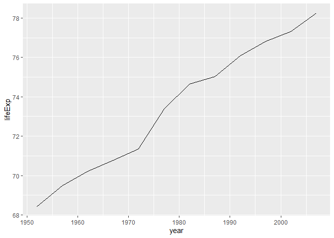

Simple Line plot

```r
library(gapminder)
library(ggplot2)

# Select a data only from a class
library(dplyr)
plot_data <- gapminder %>%
  filter(country  == "United States")
ggplot(data = plot_data,
       mapping = aes(x = year, y = lifeExp)) +
  geom_line()
```

Its hard to read all the points in the graph so lets add the points for better visualizations.

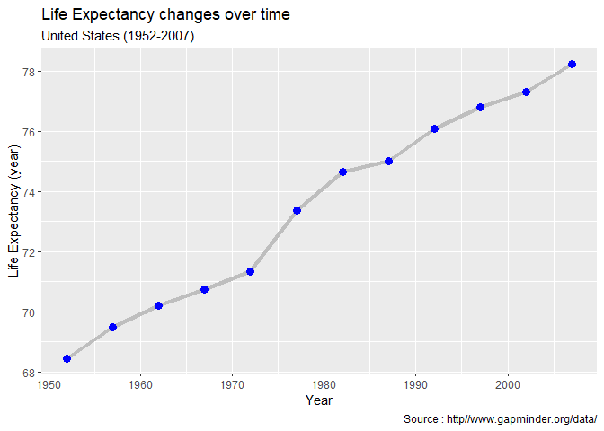

```r
# line plots with points and improved labeling
ggplot(data = plot_data,
       mapping = aes(x = year, y = lifeExp)) +
  geom_line(color = 'grey',
            size = 1.5) +
  geom_point(color = 'blue',
             size = 3) +
  labs(y = "Life Expectancy (year)",
       x = "Year",
       title = "Life Expectancy changes over time",
       subtitle = "United States (1952-2007)",
       caption = "Source : http//www.gapminder.org/data/")
```

## 3.3 Categorical vs Quantitative

When plotting the relationship between a categorical variable and a quantitative variable, a large number of graph types are available. These include bar charts using summary statistics, grouped kernel density plots, side-by-side box plots, side-by-side violin plots, mean/sem plots, ridgeline plots, and Cleveland plots. Each is considered in turn.

### 3.3.1 Bar chart (on Summary statistics)

In previous sections, bar charts were used to display the number of cases by category for a single variable or for two variables. You can also use bar charts to display other summary statistics (e.g., means or medians) on a quantitative variable for each level of a categorical variable.

For example, the following graph displays the mean salary for a sample of university professors by their academic rank.

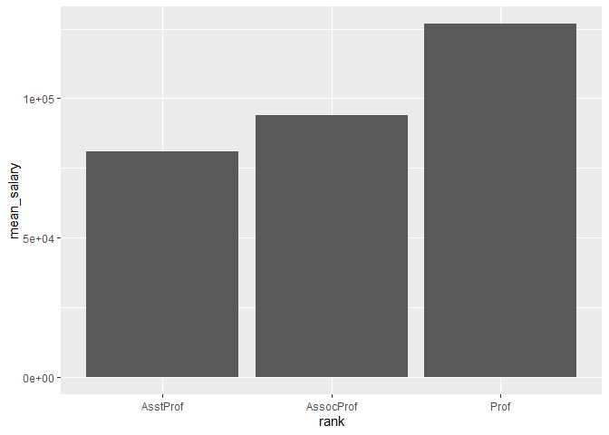

Barchart with mean salaries

```r
# load required libraries
library(carData) # for dataset Salaries
library(dplyr)
library(ggplot2)

# calculate mean salary for each rank
plot_data <- Salaries %>%
  group_by(rank) %>%
  summarise(mean_salary = mean(salary))

#plot mean salary in bar chart
ggplot(plot_data,
       aes(x = rank, y = mean_salary)) +
  geom_bar(stat = "identity")
```

Lets make it more attractive and informative.

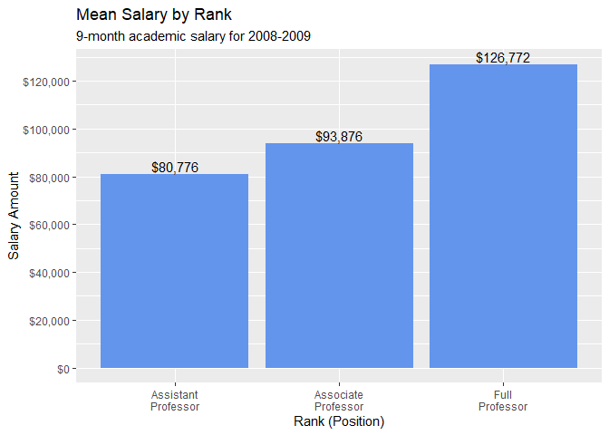

Bar chart Displaying Means

```r
# plot mean salaries in a more attractive fashion
library(scales)
ggplot(plot_data,
       aes(x = factor(rank,
                      labels = c("Assistant\nProfessor",
                                 "Associate\nProfessor",
                                 "Full\nProfessor")),
                      y = mean_salary)) +
  geom_bar(stat = "identity",
           fill = "cornflowerblue") +
  geom_text(aes(label = dollar(mean_salary)),
            vjust = -0.25) +
  scale_y_continuous(breaks = seq(0, 130000, 20000),
                     label = dollar) +
  labs(title = "Mean Salary by Rank",
       subtitle = "9-month academic salary for 2008-2009",
       x = "Rank (Position)",
       y = "Salary Amount")
```

### 3.3.2 Grouped kernel Density plots

One can compare groups on a numeric variable by superimposing kernel density plots in a single graph.

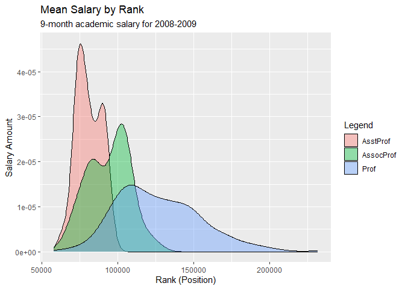

```r
# plot the distribution of salaries
# by rank using kernel density plots
ggplot(Salaries, aes(x = salary, fill = rank)) +
  geom_density(alpha = 0.4) +
  labs(title = "Mean Salary by Rank",
       subtitle = "9-month academic salary for 2008-2009",
       x = "Rank (Position)",
       y = "Salary Amount",
       fill = "Legend")
```

### 3.3.3 Box Plots

A boxplot displays the 25th percentile, median, and 75th percentile of a distribution. The whiskers (vertical lines) capture roughly 99% of a normal distribution, and observations outside this range are plotted as points representing outliers (see the figure below).

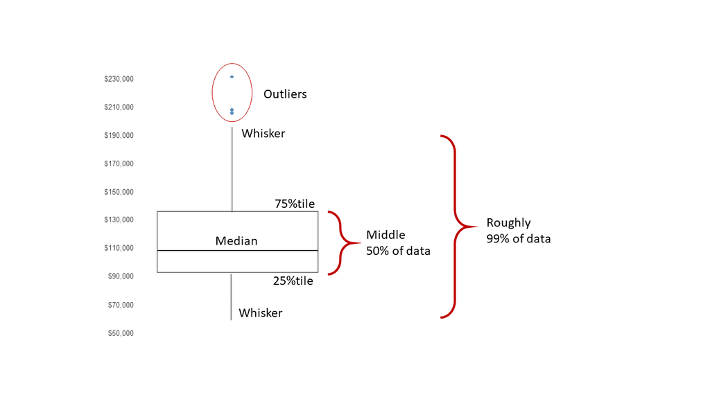

Understanding Boxplots

Side-by-side box plots are very useful for comparing groups (i.e., the levels of a categorical variable) on a numerical variable.

[figure not shown]

Box_plot2

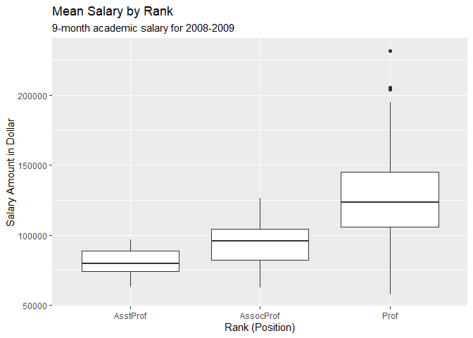

Side by side boxplot

```r
# plot the distribution of salaries by rank using boxplots
ggplot(Salaries, aes(x = rank, y = salary)) +
  geom_boxplot() +
  labs(title = "Mean Salary by Rank",
       subtitle = "9-month academic salary for 2008-2009",
       x = "Rank (Position)",
       y = "Salary Amount in Dollar")
```

Notched boxplots provide an approximate method for visualizing whether groups differ. Although not a formal test, if the notches of two boxplots do not overlap, there is strong evidence (95% confidence) that the medians of the two groups differ.

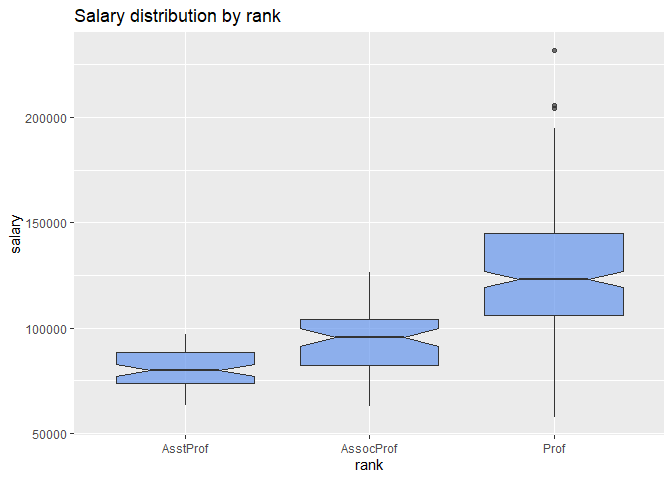

Notch Boxplot

```r
# plot the distribution of salaries by rank using boxplots
ggplot(Salaries, aes(x = rank, y = salary)) +
  geom_boxplot(notch = TRUE,
               fill = "cornflowerblue",
               alpha = .7) +
  labs(title = "Salary distribution by rank")
```

With median Values in it

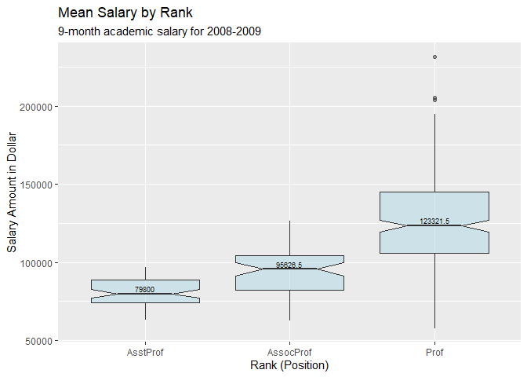

```r
ggplot(data = Salaries,
       mapping = aes(x = rank, y = salary)) +
  geom_boxplot(notch = TRUE,
               fill = 'lightblue',
               alpha = 0.5) +
  stat_summary(fun.data = "median_hilow",
               geom = "text",
               vjust = -0.35,
               size = 2.5,
               color = "black",
               aes(label = round(..y.., 2)))+
  labs(title = "Mean Salary by Rank",
       subtitle = "9-month academic salary for 2008-2009",
       x = "Rank (Position)",
       y = "Salary Amount in Dollar")
```